# student_score

```python
"""
                        Toán	Văn	    Anh	    Sử	    Địa    Lý	Hoá	    Sinh
Trần Tuấn Thông           5	     7	     9	     3	     7	    4	  8	      2
Nguyễn Hữu Nhân           3	     6	     8	     4	     9	    6	  8	      3
Nguyễn Hồng Thái          6	     3	     6	     3	     9	    0	  5	      2
Lê Ngọc Nhật Minh         4	     9	     3	     6	     5	    5	  4	      0
Hồ Anh Thư                7	     0	     0	     6	     5	    3	  4	      4
Huỳnh Trọng Minh          4	     6	     6	     1	     9	    1	  5	      5
Hà Nhật Khôi              5	     6	     1	     4	     5	    7	  4	      9
Phùng Khánh Linh          9	     4	     2	     1	     7	    4	  0	      6
Quốc Toản                 8	     6	     1	     5	     3	    2	  9	      2
Dương Sắc Minh            6	     5	     0	     2	     2	    4	  9	      6
Trí Trần                  1	     9	     5	     2	     3	    4	  7	      4
Hà Tài Nam                1	     6	     1	     1	     3	    8	  1	      7
Đỗ Quốc Hùng              5	     7	     6	     5	     9	    7	  1	      9
Nguyễn Vương Hiếu         3	     6	     4	     3	     9	    8	  7	      4
Nguyễn Thị Quốc Nguyên    6	     5	     7	     9	     2	    7	  5	      7
"""

"""
Cho data như trên, tương ứng với số điểm cuối năm của các bạn học sinh (data này là fake thôi, ko có ý gì đâu nhé)
dùng python để trả lời các câu hỏi:
    - tìm ra các học sinh bị điểm liệt. biết rằng 1 học sinh bị điểm liệt khi mà điểm thi của học sinh đó dưới 2.5.
    - cho biết có bao nhiêu môn bị liệt? và số điểm liệt của từng môn
    - Tính điểm trung bình cho cả năm học. công thức: tổng số điểm từng môn chia cho tổng số môn. làm tròn tới 2 chữ số sau dấu phẩy
    - phân loại học sinh thành: "Ở lại lớp", "Trung bình", "Khá", "Giỏi", biết:
        - học sinh "Giỏi"       : Nếu điểm trung bình >= 8.0, và không có môn nào dưới 6.5 điểm
        - học sinh "Khá"        : Nếu điểm trung bình >= 6.5, và không có môn nào dưới 5 điểm
        - học sinh "Trung bình" : Nếu điểm trung bình >= 5, và không có môn nào bị liệt
        - "Ở lại lớp"           : Nếu học sinh đó dính bất kì một điểm liệt nào

    # Từ đây trở xuống, coi như điểm của thí sinh là "Điểm thi tốt nghiệp"
    - Tính điểm tốt nghiệp của từng học sinh, biết: điểm tốt nghiệp = điểm toán nhân đôi + điểm văn nhân đôi + điểm Anh + điểm sử
    - Cho biết học sinh nào "Được tốt nghiệp" hoặc "Không đạt tốt nghiệp", biết để được công nhận xét tốt nghiệp, học sinh đó phải có điểm tốt nghiệp >= 30, và ko có môn nào bị điểm liệt
    - Nâng cao: Các thí sinh có quyền lựa chọn khối thi cho bản thân. cho biết các khối thi:
        - Khối A    : Toán - Lý - Hoá
        - Khối A1   : Toán - Lý - Anh
        - Khối B    : Toán - Hoá - Sinh
        - Khối C    : Văn - Sử - Địa
        - Khối D    : Văn - Toán - Anh

        ==> hãy cho biết: 2 nguyện vọng (2 khối thi) mà thí sinh đạt điểm cao nhất
        (Trường hợp 2 khối thi có số điểm bằng nhau thì lấy cả 2)
        Ví dụ: thi sinh Trần tuấn thông:
                - Khối A    : Toán - Lý - Hoá    = (5 + 4 + 8) = 17
                - Khối A1   : Toán - Lý - Anh    = (5 + 4 + 9) = 18
                - Khối B    : Toán - Hoá - Sinh  = (5 + 8 + 2) = 15
                - Khối C    : Văn - Sử - Địa     = (7 + 3 + 7) = 17
                - Khối D    : Văn - Toán - Anh   = (7 + 5 + 9) = 21

                ==> 2 nguyện vọng mà Trần Tuấn Thông đạt điểm cao nhất là khối D với 21 điểm và khối A1 với 18 điểm
"""
```

```
'\nCho data như trên, tương ứng với số điểm cuối năm của các bạn học sinh (data này là fake thôi, ko có ý gì đâu nhé)\ndùng python để trả lời các câu hỏi:\n    - tìm ra các học sinh bị điểm liệt. biết rằng 1 học sinh bị điểm liệt khi mà điểm thi của học sinh đó dưới 2.5.\n    - cho biết có bao nhiêu…
```

[figure not shown]

## Import Library

```python
import numpy as np
import pandas as pd
import matplotlib.pyplot as plt
import seaborn as sns
```

[figure not shown]

## Create dataframe

```python
data = {
    "Toán": [5, 3, 6, 4, 7, 4, 5, 9, 8, 6, 1, 1, 5, 3, 6],
    "Văn": [7, 6, 3, 9, 0, 6, 6, 4, 6, 5, 9, 6, 7, 6, 5],
    "Anh": [9, 8, 6, 3, 0, 6, 1, 2, 1, 0, 5, 1, 6, 4, 7],
    "Sử": [3, 4, 3, 6, 6, 1, 4, 1, 5, 2, 2, 1, 5, 3, 9],
    "Địa": [7, 9, 9, 5, 5, 9, 5, 7, 3, 2, 3, 3, 9, 9, 2],
    "Lý": [4, 6, 0, 5, 3, 1, 7, 4, 2, 4, 4, 8, 7, 8, 7],
    "Hoá": [8, 8, 5, 4, 4, 5, 4, 0, 9, 9, 7, 1, 1, 7, 5],
    "Sinh": [2, 3, 2, 0, 4, 5, 9, 6, 2, 6, 4, 7, 9, 4, 7]
}

index = [
    "Trần Tuấn Thông", "Nguyễn Hữu Nhân", "Nguyễn Hồng Thái", "Lê Ngọc Nhật Minh",
    "Hồ Anh Thư", "Huỳnh Trọng Minh", "Hà Nhật Khôi", "Phùng Khánh Linh",
    "Quốc Toản", "Dương Sắc Minh", "Trí Trần", "Hà Tài Nam",
    "Đỗ Quốc Hùng", "Nguyễn Vương Hiếu", "Nguyễn Thị Quốc Nguyên"
]

df = pd.DataFrame(data, index=index)
print("DataFrame này có 15 hàng (các học sinh) và 8 cột (các môn học). Mỗi ô trong DataFrame chứa điểm số tương ứng của một học sinh trong một môn học cụ thể.")
df
```

```
DataFrame này có 15 hàng (các học sinh) và 8 cột (các môn học). Mỗi ô trong DataFrame chứa điểm số tương ứng của một học sinh trong một môn học cụ thể.
```

|  | Toán | Văn | Anh | Sử | Địa | Lý | Hoá | Sinh |
| --- | --- | --- | --- | --- | --- | --- | --- | --- |
| Trần Tuấn Thông | 5 | 7 | 9 | 3 | 7 | 4 | 8 | 2 |
| Nguyễn Hữu Nhân | 3 | 6 | 8 | 4 | 9 | 6 | 8 | 3 |
| Nguyễn Hồng Thái | 6 | 3 | 6 | 3 | 9 | 0 | 5 | 2 |
| Lê Ngọc Nhật Minh | 4 | 9 | 3 | 6 | 5 | 5 | 4 | 0 |
| Hồ Anh Thư | 7 | 0 | 0 | 6 | 5 | 3 | 4 | 4 |
| Huỳnh Trọng Minh | 4 | 6 | 6 | 1 | 9 | 1 | 5 | 5 |
| Hà Nhật Khôi | 5 | 6 | 1 | 4 | 5 | 7 | 4 | 9 |
| Phùng Khánh Linh | 9 | 4 | 2 | 1 | 7 | 4 | 0 | 6 |
| Quốc Toản | 8 | 6 | 1 | 5 | 3 | 2 | 9 | 2 |
| Dương Sắc Minh | 6 | 5 | 0 | 2 | 2 | 4 | 9 | 6 |
| Trí Trần | 1 | 9 | 5 | 2 | 3 | 4 | 7 | 4 |
| Hà Tài Nam | 1 | 6 | 1 | 1 | 3 | 8 | 1 | 7 |
| Đỗ Quốc Hùng | 5 | 7 | 6 | 5 | 9 | 7 | 1 | 9 |
| Nguyễn Vương Hiếu | 3 | 6 | 4 | 3 | 9 | 8 | 7 | 4 |
| Nguyễn Thị Quốc Nguyên | 6 | 5 | 7 | 9 | 2 | 7 | 5 | 7 |

[figure not shown]

## Basic Analyst

> Thông tin cơ bản về DataFrame:
- Số lượng dòng (học sinh): 15
- Số lượng cột (môn học): 8
- Tên cột (môn học): "Toán", "Văn", "Anh", "Sử", "Địa", "Lý", "Hoá", "Sinh"
- Kiểu dữ liệu: Dữ liệu trong các cột là kiểu số nguyên (integer).

```python
df.info()
```

```
<class 'pandas.core.frame.DataFrame'>
Index: 15 entries, Trần Tuấn Thông to Nguyễn Thị Quốc Nguyên
Data columns (total 8 columns):
 #   Column  Non-Null Count  Dtype
---  ------  --------------  -----
 0   Toán    15 non-null     int64
 1   Văn     15 non-null     int64
 2   Anh     15 non-null     int64
 3   Sử      15 non-null     int64
 4   Địa     15 non-null     int64
 5   Lý      15 non-null     int64
 6   Hoá     15 non-null     int64
 7   Sinh    15 non-null     int64
dtypes: int64(8)
memory usage: 1.1+ KB
```

- Số lượng dòng và cột: DataFrame có tổng cộng 15 dòng (học sinh) và 8 cột (môn học).
- Kiểu dữ liệu: Tất cả các cột đều chứa kiểu dữ liệu int64, tức là các giá trị điểm số được lưu trữ dưới dạng số nguyên.
- Không có giá trị thiếu: Đối với tất cả các cột, số lượng giá trị không thiếu (non-null count) đều là 15, tức là không có giá trị nào bị thiếu trong dữ liệu.

```python
df.describe()
```

|  | Toán | Văn | Anh | Sử | Địa | Lý | Hoá | Sinh |
| --- | --- | --- | --- | --- | --- | --- | --- | --- |
| count | 15.000000 | 15.000000 | 15.000000 | 15.000000 | 15.000000 | 15.000000 | 15.000000 | 15.000000 |
| mean | 4.866667 | 5.666667 | 3.933333 | 3.666667 | 5.800000 | 4.666667 | 5.133333 | 4.666667 |
| std | 2.294922 | 2.225395 | 3.011091 | 2.257263 | 2.782599 | 2.497618 | 2.899918 | 2.663689 |
| min | 1.000000 | 0.000000 | 0.000000 | 1.000000 | 2.000000 | 0.000000 | 0.000000 | 0.000000 |
| 25% | 3.500000 | 5.000000 | 1.000000 | 2.000000 | 3.000000 | 3.500000 | 4.000000 | 2.500000 |
| 50% | 5.000000 | 6.000000 | 4.000000 | 3.000000 | 5.000000 | 4.000000 | 5.000000 | 4.000000 |
| 75% | 6.000000 | 6.500000 | 6.000000 | 5.000000 | 9.000000 | 7.000000 | 7.500000 | 6.500000 |
| max | 9.000000 | 9.000000 | 9.000000 | 9.000000 | 9.000000 | 8.000000 | 9.000000 | 9.000000 |

> Analysis cơ bản:
- count: Số lượng học sinh trong mỗi môn học, tức là số lượng giá trị trong mỗi cột.
- mean: Giá trị trung bình của điểm số trong mỗi môn học.
- std: Độ lệch chuẩn, cho biết mức độ phân tán của dữ liệu quanh giá trị trung bình.
- min: Giá trị điểm số thấp nhất trong mỗi môn học.
- 25%: Điểm số ở phân vị 25%, tức là 25% số học sinh có điểm thấp hơn giá trị này.
- 50%: Điểm số ở phân vị 50%, tương đương với giá trị trung vị (median), chia dữ liệu thành hai phần bằng nhau.
- 75%: Điểm số ở phân vị 75%, tức là 25% số học sinh có điểm cao hơn giá trị này.
- max: Giá trị điểm số cao nhất trong mỗi môn học.

[figure not shown]

## Tiền xử lý dữ liệu

> cái này bỏ qua vì dữ liệu đã sạch

[figure not shown]

## Khám phá dữ liệu

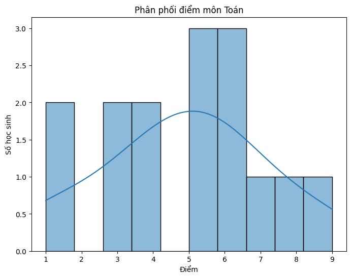

```python
# Vẽ biểu đồ phân phối của điểm số môn Toán
plt.figure(figsize=(8, 6))
sns.histplot(df['Toán'], bins=10, kde=True)
plt.title('Phân phối điểm môn Toán')
plt.xlabel('Điểm')
plt.ylabel('Số học sinh')
```

> Biểu đồ phân phối (histogram) là một cách thể hiện sự phân bố của dữ liệu trong các khoảng giá trị khác nhau. Khi xem biểu đồ phân phối, chúng ta sẽ nhìn thấy cách dữ liệu được chia thành các khoảng (hay còn gọi là bin) và có bao nhiêu dữ liệu nằm trong mỗi khoảng đó. Biểu đồ phân phối giúp chúng ta có cái nhìn tổng quan về sự phân bố của dữ liệu và có thể phát hiện ra những đặc điểm quan trọng.

> Trong trường hợp của biểu đồ phân phối điểm môn Toán đã vẽ:
> - Trục X (Điểm): Đây là trục ngang của biểu đồ, thể hiện giá trị điểm trong môn Toán. Các khoảng giá trị điểm (bin) sẽ nằm trên trục này.
> - Trục Y (Số học sinh): Đây là trục đứng của biểu đồ, thể hiện số lượng học sinh nằm trong từng khoảng điểm tương ứng. Ví dụ, nếu thấy một thanh cột lớn tại khoảng điểm 6, điều này có nghĩa là có nhiều học sinh có điểm là 6.
> - Các thanh cột (bars): Các thanh cột trên biểu đồ thể hiện số lượng học sinh nằm trong từng khoảng điểm. Ví dụ, nếu có một thanh cột dày và cao ở khoảng điểm 5, điều này có nghĩa là có nhiều học sinh có điểm xấp xỉ 5.
> - Đường cong màu xanh (KDE - Kernel Density Estimation): Đây là đường cong mịn màng màu xanh nằm trên các thanh cột. Dòng cong này giúp bạn ước tính hình dáng của phân phối dữ liệu dưới dạng mật độ xác suất. Khi dòng cong nâng lên ở một vùng nào đó, điều này cho thấy nhiều dữ liệu tập trung ở vùng đó.

> Tóm lại, biểu đồ phân phối giúp chúng ta nhận biết sự phân bố của điểm số môn Toán, đặc biệt là xác định các khoảng điểm có số lượng học sinh nhiều nhất và những vùng mà điểm số tập trung.

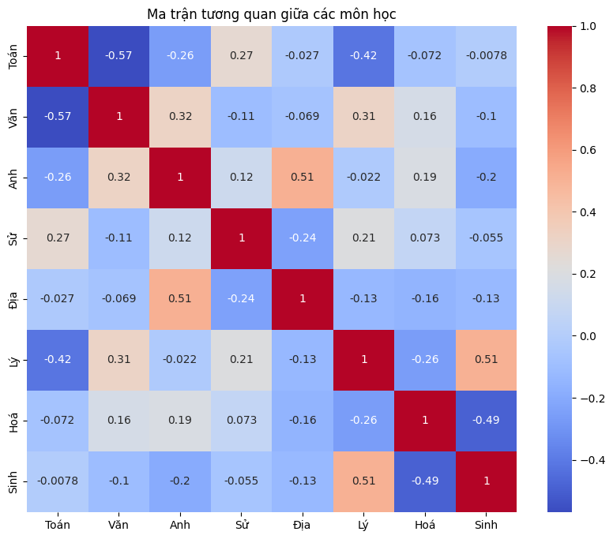

```python
# Vẽ ma trận biểu đồ tương quan giữa các môn học
plt.figure(figsize=(10, 8))
sns.heatmap(df.corr(), annot=True, cmap='coolwarm')
plt.title('Ma trận tương quan giữa các môn học')
plt.show()
```

> Ma trận biểu đồ tương quan (correlation heatmap) giữa các môn học giúp chúng ta hiểu về mối quan hệ tương quan giữa các cặp môn học. Tương quan đo lường mức độ liên quan giữa hai biến, trong trường hợp này, là điểm số giữa các môn học.

> Để hiểu cách đọc ma trận biểu đồ tương quan:
> - Ô vuông trên đường chéo chính: Đây là những ô vuông màu đỏ chứa số 1.0. Điều này thể hiện mối tương quan hoàn hảo giữa một biến với chính nó, vì chúng ta đang so sánh biến với chính nó.
> - Các ô vuông màu khác: Các ô vuông nằm ngoài đường chéo chính (đường chéo từ trái trên đến phải dưới) chứa các giá trị tương quan từ -1.0 đến 1.0. Màu sắc của ô vuông biểu thị mức độ tương quan: màu càng tối thể hiện tương quan càng mạnh (gần 1 hoặc -1), màu càng sáng thể hiện tương quan càng yếu (gần 0).
> - Chú thích về màu sắc: Bên cạnh biểu đồ, có thể có một chú thích màu sắc, thường được đặt ở bên cạnh ma trận. Nó cho biết mức độ tương quan tương ứng với màu sắc.
> - Số liệu bên trong ô vuông: Nếu thấy dấu số bên trong ô vuông, đó là giá trị tương quan số liệu thực. Số liệu này thể hiện mức độ tương quan chính xác giữa hai biến.

> Khi nhìn vào ma trận biểu đồ tương quan, có thể thấy mối quan hệ giữa các cặp môn học. Một giá trị tương quan gần với 1.0 có nghĩa là có mối tương quan dương mạnh (tăng cùng nhau), trong khi giá trị tương quan gần -1.0 thể hiện mối tương quan âm mạnh (khi một biến tăng thì biến còn lại giảm). Giá trị tương quan gần 0 thể hiện mối tương quan yếu hoặc không có mối quan hệ tương quan.

```python
# Tìm học sinh có điểm cao nhất và thấp nhất trong mỗi môn học
max_scores = df.idxmax()
min_scores = df.idxmin()

print("Học sinh có điểm cao nhất:")
print(max_scores)

print("\nHọc sinh có điểm thấp nhất:")
print(min_scores)
```

```
Học sinh có điểm cao nhất:
Toán          Phùng Khánh Linh
Văn          Lê Ngọc Nhật Minh
Anh            Trần Tuấn Thông
Sử      Nguyễn Thị Quốc Nguyên
Địa            Nguyễn Hữu Nhân
Lý                  Hà Tài Nam
Hoá                  Quốc Toản
Sinh              Hà Nhật Khôi
dtype: object

Học sinh có điểm thấp nhất:
Toán             Trí Trần
Văn            Hồ Anh Thư
Anh            Hồ Anh Thư
Sử       Huỳnh Trọng Minh
Địa        Dương Sắc Minh
Lý       Nguyễn Hồng Thái
Hoá      Phùng Khánh Linh
Sinh    Lê Ngọc Nhật Minh
dtype: object
```

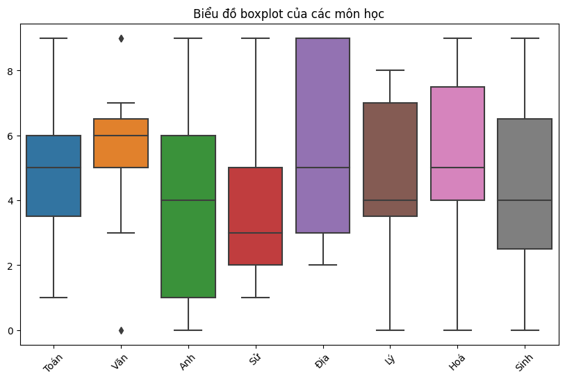

```python
# Tạo biểu đồ boxplot để phát hiện biến đổi bất thường
plt.figure(figsize=(10, 6))
sns.boxplot(data=df)
plt.title('Biểu đồ boxplot của các môn học')
plt.xticks(rotation=45)
plt.show()
```

> Biểu đồ boxplot là một công cụ mạnh để phát hiện sự biến đổi bất thường và hiểu về phân phối của dữ liệu trong mỗi biến
> - Hộp (Box): Phần hộp chứa giữa một phần tử thứ nhất và phần tử thứ ba của tập dữ liệu (25% và 75% phân vị), gọi là khoảng giữa tứ phân vị (IQR). Khoảng giữa tứ phân vị thể hiện phạm vi mà dữ liệu phân bố chủ yếu.
> - Đường kẻ ở giữa hộp (Median): Đây là giá trị trung vị của dữ liệu, tức là giá trị nằm ở giữa khi tập dữ liệu được sắp xếp theo thứ tự.
> - Vành (Whiskers): Vành trên và dưới biểu diễn khoảng từ giá trị thấp nhất/kéo đến phân vị thứ nhất (Q1 - 1.5IQR) đến giá trị cao nhất/kéo đến phân vị thứ ba (Q3 + 1.5IQR). Dữ liệu nằm ngoài khoảng này thường được coi là điểm ngoại lai (outliers).
> - Các điểm ngoại lai (Outliers): Những điểm nằm ngoài vùng vạch hình thang (vành) thường được hiển thị dưới dạng các điểm riêng biệt. Chúng có thể là dữ liệu biến đổi bất thường hoặc là các giá trị sai lệch so với phân phối chung.

> Biểu đồ boxplot giúp xác định sự biến đổi bất thường, phân phối dữ liệu và trung vị của biến, cũng như phân phối của dữ liệu xung quanh median. Nếu thấy rất nhiều điểm ngoại lai hoặc biểu đồ không đối xứng, điều này có thể gợi ý rằng dữ liệu của bạn có những biến đổi bất thường hoặc chưa tuân theo phân phối chuẩn.

[figure not shown]

## Phân tích và mô hình hóa:

> Để phân tích và mô hình hóa dữ liệu, chúng ta có thể đặt ra các câu hỏi cụ thể về mục tiêu của mình
> 1. Câu hỏi: Liệu có mối quan hệ giữa điểm số các môn học với nhau không?

> Phân tích: có thể thực hiện phân tích tương quan giữa các cặp môn học bằng cách tính ma trận tương quan hoặc vẽ biểu đồ tương quan. Nếu có mối tương quan mạnh, điều này có thể gợi ý rằng học sinh có xu hướng đạt điểm cao (hoặc thấp) trong nhiều môn học cùng lúc.
> 2. Câu hỏi: Môn học nào có điểm trung bình cao nhất và thấp nhất?

> Phân tích: có thể tính trung bình điểm của từng môn học và tìm môn có điểm trung bình cao nhất và thấp nhất. Điều này sẽ giúp chúng ta hiểu rõ hơn về hiệu suất của học sinh trong từng môn học.
> 3. Câu hỏi: Có sự biến đổi bất thường (outliers) trong điểm số không?

> Phân tích: ta đã vẽ biểu đồ boxplot để phát hiện biến đổi bất thường. Nếu thấy nhiều điểm ngoại lai trong biểu đồ, có thể xem xét xem liệu chúng có xuất phát từ sự biến đổi thực sự hoặc là do lỗi nhập liệu.
> 4. Câu hỏi: Liệu có mối quan hệ giữa điểm số và số lượng học sinh không?

> Phân tích: có thể thực hiện phân tích tương quan giữa điểm số và số lượng học sinh trong từng khoảng điểm bằng cách sử dụng biểu đồ tương quan hoặc tính hệ số tương quan. Điều này có thể giúp hiểu xem liệu có mối quan hệ giữa điểm số và số lượng học sinh không.
> 5. Câu hỏi: Liệu có sự khác biệt đáng kể về điểm số giữa các môn học không?

> Phân tích: có thể thực hiện phân tích so sánh điểm số giữa các môn học bằng các phương pháp như kiểm định Anova (nếu có nhiều môn học hơn để so sánh) hoặc t-test (nếu so sánh từng cặp môn học).

> Nếu muốn xây dựng mô hình dự đoán hoặc phân loại, bạn có thể sử dụng các thuật toán Machine Learning như Linear Regression, Decision Trees, Random Forest, hoặc Neural Networks. Tuy nhiên, việc xây dựng mô hình cần phải dựa trên mục tiêu cụ thể và cân nhắc sự phức tạp của bài toán.

[figure not shown]

## Trực Quan Hoá Dữ Liệu

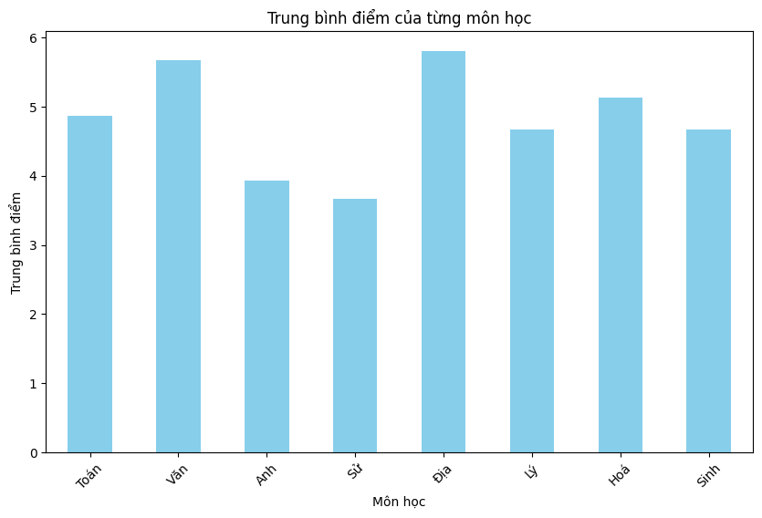

```python
plt.figure(figsize=(10, 6))
df.mean().plot(kind='bar', color='skyblue')
plt.title('Trung bình điểm của từng môn học')
plt.xlabel('Môn học')
plt.ylabel('Trung bình điểm')
plt.xticks(rotation=45)
plt.show()
```

> Biểu đồ cột trung bình điểm của từng môn học thể hiện mức trung bình điểm của tất cả học sinh trong từng môn học khác nhau. Mỗi cột trên biểu đồ đại diện cho một môn học, chiều cao của cột thể hiện giá trị trung bình điểm của môn học đó.

> Cụ thể, từ biểu đồ cột trung bình điểm của từng môn học
> - Môn học có trung bình điểm cao nhất: Có thể xác định môn học có điểm trung bình cao nhất bằng cách xem cột có giá trị cao nhất trên biểu đồ.
> - Môn học có trung bình điểm thấp nhất: Tương tự, có thể xác định môn học có điểm trung bình thấp nhất bằng cách xem cột có giá trị thấp nhất trên biểu đồ.
> - So sánh điểm trung bình giữa các môn học: Biểu đồ cho phép so sánh trực quan điểm trung bình giữa các môn học. Nếu có sự chênh lệch lớn giữa các cột, điều này có thể gợi ý rằng môn học đó có sự khác biệt rõ rệt về điểm số giữa các học sinh.
> - Điểm số trung bình của môn học: có thể nhận thấy mức độ tập trung của điểm số trong từng môn học qua chiều cao của cột trung bình. Nếu cột có chiều cao cao và đồng đều, điều này có thể cho thấy điểm số tập trung ở một khoảng rộng. Nếu cột có chiều cao thấp hoặc biến đổi lớn, điều này có thể gợi ý sự biến đổi trong điểm số của môn học.

> Tóm lại, biểu đồ cột này giúp hiểu và so sánh điểm trung bình của các môn học một cách trực quan và dễ dàng.

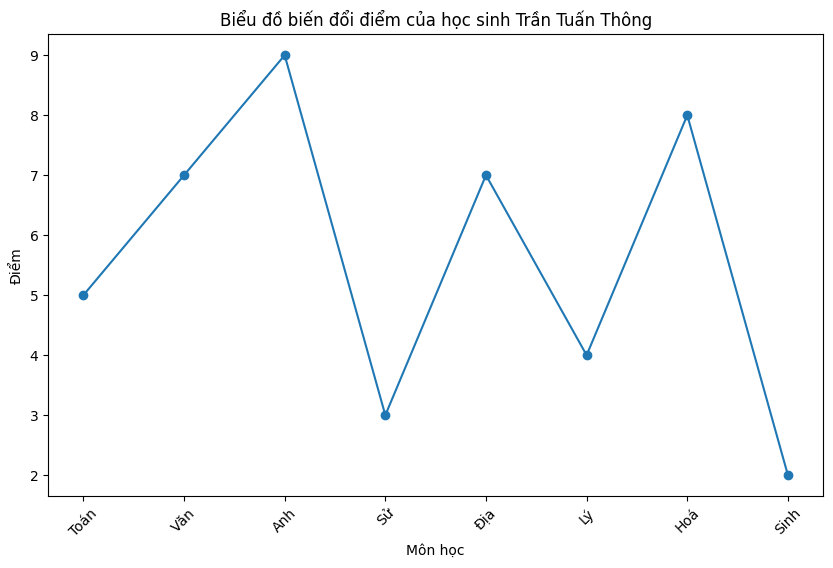

```python
student_name = "Trần Tuấn Thông"
student_scores = df.loc[student_name]

plt.figure(figsize=(10, 6))
plt.plot(student_scores, marker='o')
plt.title(f'Biểu đồ biến đổi điểm của học sinh {student_name}')
plt.xlabel('Môn học')
plt.ylabel('Điểm')
plt.xticks(rotation=45)
plt.show()
```

> Biểu đồ biến đổi điểm của học sinh "Trần Tuấn Thông" thể hiện sự biến đổi của điểm số qua các môn học. Mỗi điểm trên biểu đồ đại diện cho điểm số của học sinh "Trần Tuấn Thông" trong mỗi môn học tương ứng.

> Từ biểu đồ, có thể hiểu được:

> -Mối quan hệ giữa điểm và môn học: Biểu đồ cho thấy cách điểm số của học sinh này thay đổi theo từng môn học. có thể thấy được sự biến đổi và chênh lệch điểm số giữa các môn học.

> -Hiệu suất trong từng môn học: có thể xác định được học sinh này có hiệu suất tốt nhất trong môn nào, và môn nào có điểm số thấp nhất. Điều này giúp hiểu rõ hơn về sở trường và khó khăn của học sinh trong từng môn học.

> -Mức độ biến đổi: Nếu biểu đồ có nhiều biến đổi đột ngột, điều này có thể gợi ý rằng học sinh có sự biến đổi lớn trong điểm số giữa các môn học. Ngược lại, nếu biểu đồ có sự biến đổi nhẹ hoặc duy trì ổn định, điều này có thể cho thấy học sinh duy trì mức độ ổn định hơn trong điểm số.

> Tóm lại, biểu đồ biến đổi điểm của học sinh giúp hình dung và theo dõi cách điểm số thay đổi qua các môn học, từ đó hiểu rõ hơn về hiệu suất và biến đổi của học sinh trong học tập.

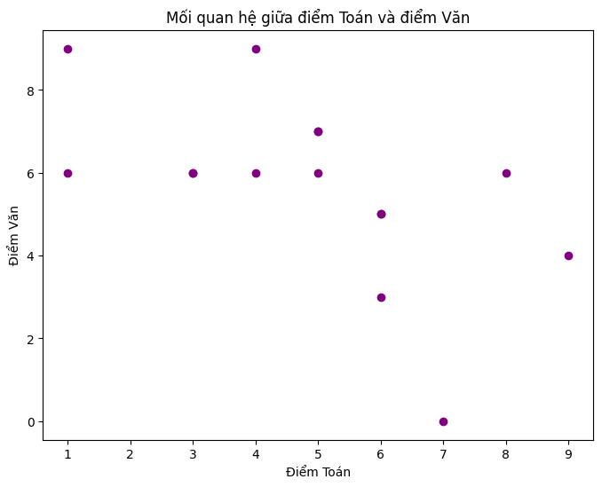

```python
plt.figure(figsize=(8, 6))
plt.scatter(df['Toán'], df['Văn'], color='purple')
plt.title('Mối quan hệ giữa điểm Toán và điểm Văn')
plt.xlabel('Điểm Toán')
plt.ylabel('Điểm Văn')
plt.show()
```

> Biểu đồ scatter (hay còn gọi là biểu đồ phân tán) thể hiện mối quan hệ giữa hai biến, trong trường hợp này là điểm số môn Toán và điểm số môn Văn của các học sinh. Mỗi điểm trên biểu đồ đại diện cho một học sinh và vị trí của điểm đó trên trục x (Điểm Toán) và trục y (Điểm Văn) thể hiện điểm số của học sinh đó trong hai môn tương ứng.

> Từ biểu đồ scatter, có thể rút ra một số thông tin như sau:
> - Mối quan hệ dự đoán: có thể quan sát liệu có một mối quan hệ dự đoán giữa điểm Toán và điểm Văn không. Nếu các điểm trên biểu đồ có xu hướng tập trung thành một dải hoặc có hình dáng gợi ý một mô hình (ví dụ: hình chữ L), điều này có thể cho thấy một mối quan hệ dự đoán giữa hai biến.
> - Phân phối điểm: có thể thấy được phân phối của điểm số trong mỗi môn học. Nếu điểm số tập trung trong một khoảng cụ thể và không có sự phân tán lớn, điều này có thể cho thấy điểm số của hai môn học tương tự nhau.
> - Điểm ngoại lai: Các điểm cách xa khỏi nhóm chung có thể là các điểm ngoại lai, tương ứng với các học sinh có điểm số thấp hoặc cao hơn so với phần lớn.

> Tóm lại, biểu đồ scatter cho thấy mối quan hệ giữa hai biến và hiểu rõ hơn về phân phối điểm số trong từng môn học, cũng như xác định các điểm ngoại lai.

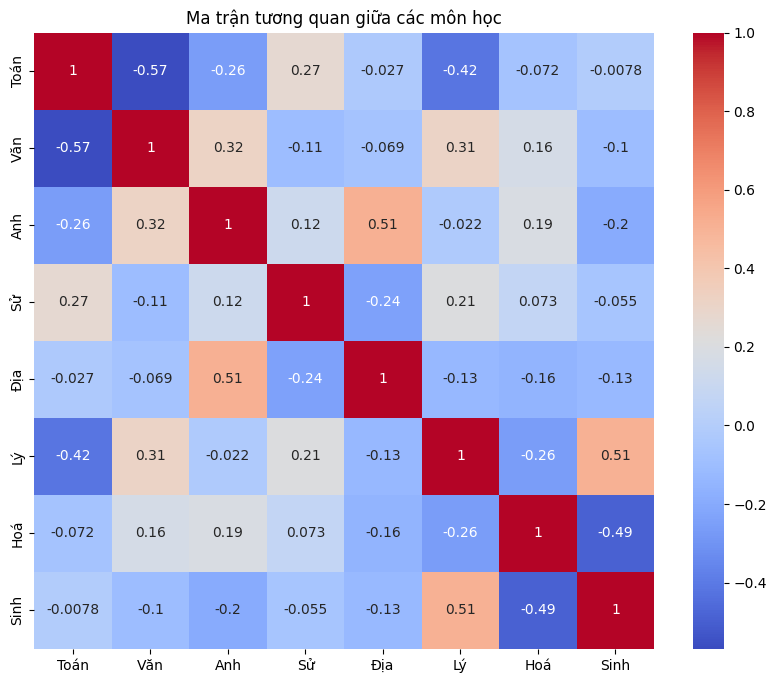

```python
plt.figure(figsize=(10, 8))
sns.heatmap(df.corr(), annot=True, cmap='coolwarm')
plt.title('Ma trận tương quan giữa các môn học')
plt.show()
```

> Biểu đồ heatmap (biểu đồ nhiệt) thể hiện ma trận tương quan giữa các biến, trong trường hợp này là tương quan giữa điểm số các môn học. Mỗi ô trên biểu đồ có màu sắc thể hiện mức độ tương quan giữa hai biến tương ứng (hàng và cột tương ứng với các môn học).

> Tóm lại, biểu đồ heatmap giúp bạn thấy mối quan hệ tương quan giữa các môn học và phân tích được cách các môn tương tác với nhau.

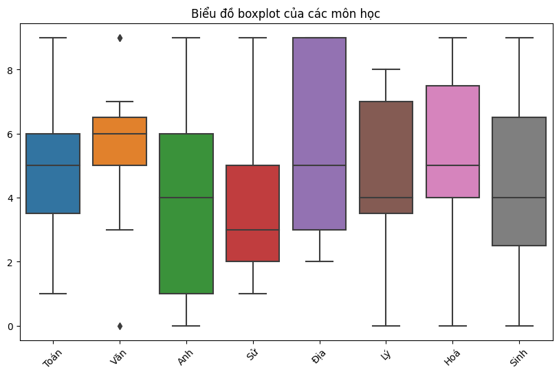

```python
plt.figure(figsize=(10, 6))
sns.boxplot(data=df)
plt.title('Biểu đồ boxplot của các môn học')
plt.xticks(rotation=45)
plt.show()
```

> Biểu đồ boxplot (biểu đồ hộp) thể hiện phân phối và biến đổi của điểm số trong từng môn học. Mỗi hộp trên biểu đồ biểu diễn phân phối của điểm trong một môn học cụ thể, còn các điểm ngoại lai (outliers) có thể được hiển thị ngoài hộp.

> Từ biểu đồ boxplot, có thể hiểu được:
> - Phân phối điểm: Hộp trên biểu đồ thể hiện phân phối điểm trong môn học tương ứng. Điểm ở giữa hộp thể hiện giá trị trung vị (median) của phân phối, còn độ dài của hộp thể hiện phạm vi giữa các phần tư (25% đến 75%) của phân phối.
> - Điểm ngoại lai: Các điểm ngoại lai (outliers) được hiển thị bằng các dấu '+' hoặc các dấu 'o' nằm ngoài hộp. Điểm ngoại lai là các điểm có giá trị độc đáo và không nằm trong phạm vi phân phối chính.
> - So sánh biến đổi: So sánh chiều dài và độ biến đổi của các hộp có thể giúp nhận biết môn học nào có biến đổi lớn hơn so với môn học khác. Nếu hộp dài hơn, có thể có sự biến đổi lớn hơn trong điểm số.
> - Phát hiện điểm ngoại lai: Biểu đồ boxplot cũng giúp dễ dàng phát hiện điểm ngoại lai, tức là các điểm có giá trị độc đáo và có thể là dấu hiệu của sự bất thường trong dữ liệu.

> Tóm lại, biểu đồ boxplot giúp hiểu về phân phối và biến đổi của điểm số trong từng môn học, cũng như phát hiện điểm ngoại lai trong dữ liệu.

[figure not shown]

## Some Question

```python
# tìm ra các học sinh bị điểm liệt. biết rằng 1 học sinh bị điểm liệt khi mà điểm thi của học sinh đó dưới 2.5.

diem_liet = df[df < 2.5].dropna(how='all')
hoc_sinh_bien_liet = diem_liet.index.tolist()

print("Các học sinh bị điểm liệt:")
for hoc_sinh in hoc_sinh_bien_liet:
    print(hoc_sinh)
```

```
Các học sinh bị điểm liệt:
Trần Tuấn Thông
Nguyễn Hồng Thái
Lê Ngọc Nhật Minh
Hồ Anh Thư
Huỳnh Trọng Minh
Hà Nhật Khôi
Phùng Khánh Linh
Quốc Toản
Dương Sắc Minh
Trí Trần
Hà Tài Nam
Đỗ Quốc Hùng
Nguyễn Thị Quốc Nguyên
```

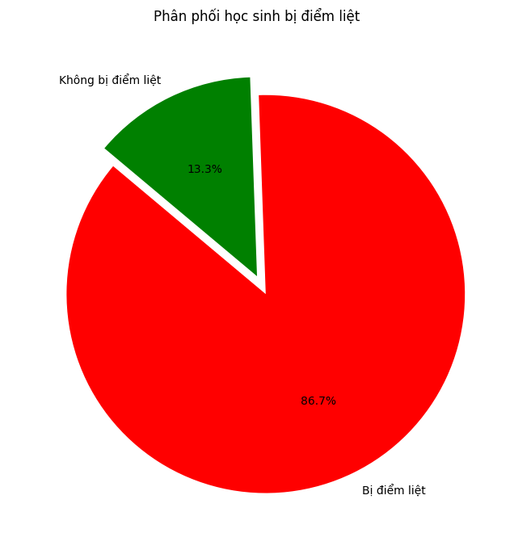

```python
# Số lượng học sinh bị điểm liệt và không bị điểm liệt
hoc_sinh_liet = len(hoc_sinh_bien_liet)
hoc_sinh_khong_liet = len(df) - hoc_sinh_liet

# Dữ liệu cho biểu đồ tròn
labels = ['Bị điểm liệt', 'Không bị điểm liệt']
sizes = [hoc_sinh_liet, hoc_sinh_khong_liet]
colors = ['red', 'green']
explode = (0.1, 0)  # Phân tách mảnh 'Bị điểm liệt'

# Vẽ biểu đồ tròn
plt.figure(figsize=(8, 8))
plt.pie(sizes, labels=labels, colors=colors, autopct='%1.1f%%', startangle=140, explode=explode)
plt.title('Phân phối học sinh bị điểm liệt')
plt.show()
```

```python
# tìm ra các học sinh bị điểm liệt. biết rằng 1 học sinh bị điểm liệt khi mà điểm thi của học sinh đó dưới 2.5. nói rõ học sinh nào bị liệt môn nào với số điểm bao nhiêu
# Tạo DataFrame chứa điểm liệt của từng học sinh
diem_liet_hs = df < 2.5

# Tạo DataFrame chứa điểm liệt của từng môn cho từng học sinh
diem_liet_moi_mon = df[df < 2.5]

# Lấy danh sách các học sinh bị điểm liệt ít nhất một môn
hoc_sinh_bi_liet = diem_liet_hs[diem_liet_hs.any(axis=1)]

# In ra thông tin về học sinh bị điểm liệt và số điểm liệt của từng môn
for hs, mons_liet in hoc_sinh_bi_liet.iterrows():
    mons_liet = mons_liet[mons_liet].index.tolist()
    diem_liet = diem_liet_moi_mon.loc[hs, mons_liet].tolist()
    print(f"Học sinh {hs} bị điểm liệt môn: ")
    for mon, diem in zip(mons_liet, diem_liet):
        print(f"{mon} với số điểm: {diem}")
```

```
Học sinh Trần Tuấn Thông bị điểm liệt môn:
Sinh với số điểm: 2.0
Học sinh Nguyễn Hồng Thái bị điểm liệt môn:
Lý với số điểm: 0.0
Sinh với số điểm: 2.0
Học sinh Lê Ngọc Nhật Minh bị điểm liệt môn:
Sinh với số điểm: 0.0
Học sinh Hồ Anh Thư bị điểm liệt môn:
Văn với số điểm: 0.0
Anh với số điểm: 0.0
Học sinh Huỳnh Trọng Minh bị điểm liệt môn:
Sử với số điểm: 1.0
Lý với số điểm: 1.0
Học sinh Hà Nhật Khôi bị điểm liệt môn:
Anh với số điểm: 1.0
Học sinh Phùng Khánh Linh bị điểm liệt môn:
Anh với số điểm: 2.0
Sử với số điểm: 1.0
Hoá với số điểm: 0.0
Học sinh Quốc Toản bị điểm liệt môn:
Anh với số điểm: 1.0
Lý với số điểm: 2.0
Sinh với số điểm: 2.0
Học sinh Dương Sắc Minh bị điểm liệt môn:
Anh với số điểm: 0.0
Sử với số điểm: 2.0
Địa với số điểm: 2.0
Học sinh Trí Trần bị điểm liệt môn:
Toán với số điểm: 1.0
Sử với số điểm: 2.0
Học sinh Hà Tài Nam bị điểm liệt môn:
Toán với số điểm: 1.0
Anh với số điểm: 1.0
Sử với số điểm: 1.0
Hoá với số điểm: 1.0
Học sinh Đỗ Quốc Hùng bị điểm liệt môn:
Hoá với số điểm: 1.0
Học sinh Nguyễn Thị Quốc Nguyên bị điểm liệt môn:
Địa với số điểm: 2.0
```

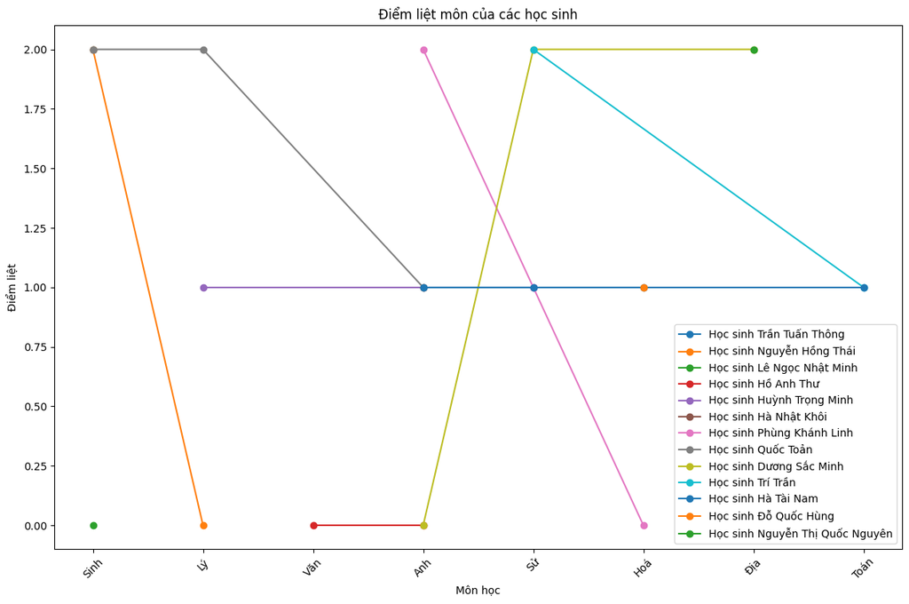

```python
# Tạo DataFrame chứa điểm liệt của từng học sinh
diem_liet_hs = df < 2.5

# Tạo DataFrame chứa điểm liệt của từng môn cho từng học sinh
diem_liet_moi_mon = df[df < 2.5]

# Lấy danh sách các học sinh bị điểm liệt ít nhất một môn
hoc_sinh_bi_liet = diem_liet_hs[diem_liet_hs.any(axis=1)]

# Tạo biểu đồ dòng để trực quan hóa thông tin
plt.figure(figsize=(12, 8))
for hs, mons_liet in hoc_sinh_bi_liet.iterrows():
    mons_liet = mons_liet[mons_liet].index.tolist()
    diem_liet = diem_liet_moi_mon.loc[hs, mons_liet].tolist()
    plt.plot(mons_liet, diem_liet, marker='o', label=f'Học sinh {hs}')

plt.title('Điểm liệt môn của các học sinh')
plt.xlabel('Môn học')
plt.ylabel('Điểm liệt')
plt.xticks(rotation=45)
plt.legend()
plt.tight_layout()
plt.show()
```

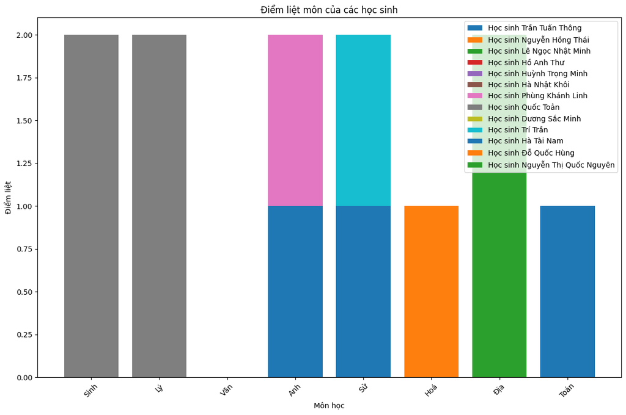

```python
# Tạo DataFrame chứa điểm liệt của từng học sinh
diem_liet_hs = df < 2.5

# Tạo DataFrame chứa điểm liệt của từng môn cho từng học sinh
diem_liet_moi_mon = df[df < 2.5]

# Lấy danh sách các học sinh bị điểm liệt ít nhất một môn
hoc_sinh_bi_liet = diem_liet_hs[diem_liet_hs.any(axis=1)]

# Tạo biểu đồ cột để trực quan hóa thông tin
plt.figure(figsize=(12, 8))
for hs, mons_liet in hoc_sinh_bi_liet.iterrows():
    mons_liet = mons_liet[mons_liet].index.tolist()
    diem_liet = diem_liet_moi_mon.loc[hs, mons_liet].tolist()
    plt.bar(mons_liet, diem_liet, label=f'Học sinh {hs}')

plt.title('Điểm liệt môn của các học sinh')
plt.xlabel('Môn học')
plt.ylabel('Điểm liệt')
plt.xticks(rotation=45)
plt.legend()
plt.tight_layout()
plt.show()
```

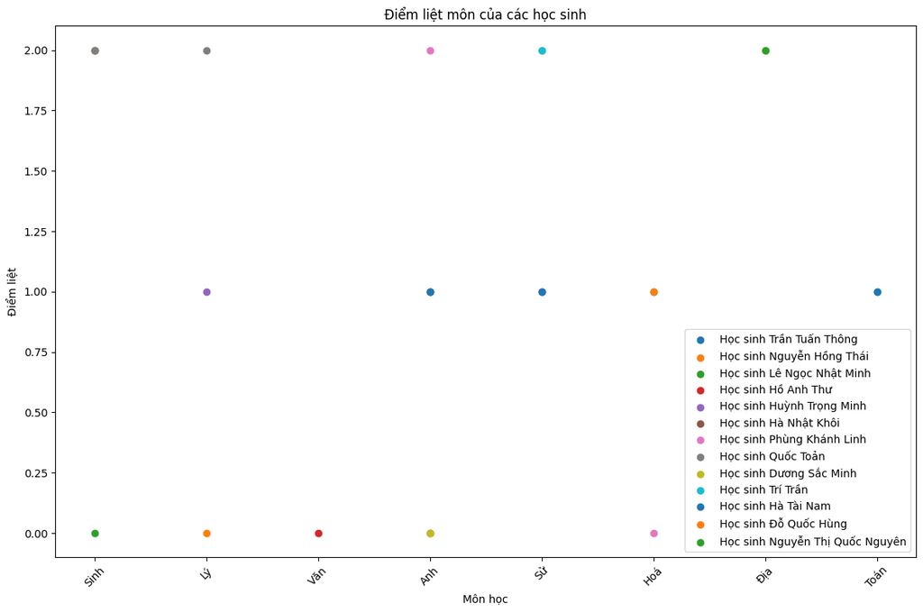

```python
# Tạo DataFrame chứa điểm liệt của từng học sinh
diem_liet_hs = df < 2.5

# Tạo DataFrame chứa điểm liệt của từng môn cho từng học sinh
diem_liet_moi_mon = df[df < 2.5]

# Lấy danh sách các học sinh bị điểm liệt ít nhất một môn
hoc_sinh_bi_liet = diem_liet_hs[diem_liet_hs.any(axis=1)]

# Tạo biểu đồ điểm để trực quan hóa thông tin
plt.figure(figsize=(12, 8))
for hs, mons_liet in hoc_sinh_bi_liet.iterrows():
    mons_liet = mons_liet[mons_liet].index.tolist()
    diem_liet = diem_liet_moi_mon.loc[hs, mons_liet].tolist()
    plt.scatter(mons_liet, diem_liet, label=f'Học sinh {hs}')

plt.title('Điểm liệt môn của các học sinh')
plt.xlabel('Môn học')
plt.ylabel('Điểm liệt')
plt.xticks(rotation=45)
plt.legend()
plt.tight_layout()
plt.show()
```

```python
# - cho biết có bao nhiêu môn bị liệt? và số điểm liệt của từng môn
# Tính số điểm liệt của từng môn
diem_liet_moi_mon = df[df < 2.5].count()

# Lọc ra các môn bị liệt
mon_bi_liet = diem_liet_moi_mon[diem_liet_moi_mon > 0]

# Số môn bị liệt
so_mon_bi_liet = len(mon_bi_liet)

print(f"Số môn bị liệt: {so_mon_bi_liet}")
print("Số điểm liệt của từng môn:")
for mon, so_diem_liet in mon_bi_liet.items():
    print(f"{mon}: {so_diem_liet} điểm")
```

```
Số môn bị liệt: 8
Số điểm liệt của từng môn:
Toán: 2 điểm
Văn: 1 điểm
Anh: 6 điểm
Sử: 5 điểm
Địa: 2 điểm
Lý: 3 điểm
Hoá: 3 điểm
Sinh: 4 điểm
```

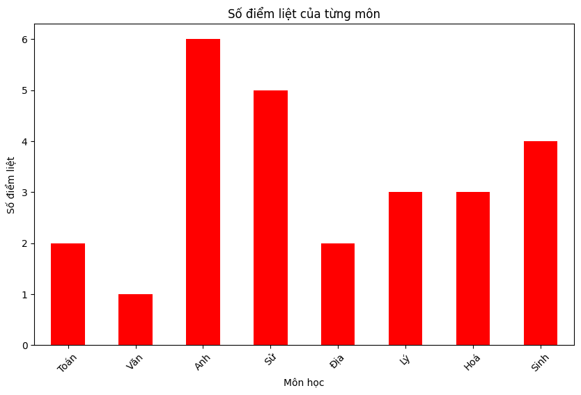

```python
# Tính số điểm liệt của từng môn
diem_liet_moi_mon = df[df < 2.5].count()

# Lọc ra các môn bị liệt
mon_bi_liet = diem_liet_moi_mon[diem_liet_moi_mon > 0]

# Vẽ biểu đồ cột
plt.figure(figsize=(10, 6))
mon_bi_liet.plot(kind='bar', color='red')
plt.title('Số điểm liệt của từng môn')
plt.xlabel('Môn học')
plt.ylabel('Số điểm liệt')
plt.xticks(rotation=45)
plt.show()
```

```python
# - Tính điểm trung bình cho cả năm học của từng học sinh. công thức: tổng số điểm từng môn chia cho tổng số môn. làm tròn tới 2 chữ số sau dấu phẩy
# Tính tổng số điểm từng học sinh
tong_diem_moi_hs = df.sum(axis=1)

# Tính điểm trung bình cho cả năm học của từng học sinh
diem_trung_binh_hs = (tong_diem_moi_hs / df.shape[1]).round(2)

# In ra điểm trung bình cho cả năm học của từng học sinh
for hs, diem_tb in diem_trung_binh_hs.items():
    print(f"Điểm trung bình của học sinh {hs}: {diem_tb}")
```

```
Điểm trung bình của học sinh Trần Tuấn Thông: 5.62
Điểm trung bình của học sinh Nguyễn Hữu Nhân: 5.88
Điểm trung bình của học sinh Nguyễn Hồng Thái: 4.25
Điểm trung bình của học sinh Lê Ngọc Nhật Minh: 4.5
Điểm trung bình của học sinh Hồ Anh Thư: 3.62
Điểm trung bình của học sinh Huỳnh Trọng Minh: 4.62
Điểm trung bình của học sinh Hà Nhật Khôi: 5.12
Điểm trung bình của học sinh Phùng Khánh Linh: 4.12
Điểm trung bình của học sinh Quốc Toản: 4.5
Điểm trung bình của học sinh Dương Sắc Minh: 4.25
Điểm trung bình của học sinh Trí Trần: 4.38
Điểm trung bình của học sinh Hà Tài Nam: 3.5
Điểm trung bình của học sinh Đỗ Quốc Hùng: 6.12
Điểm trung bình của học sinh Nguyễn Vương Hiếu: 5.5
Điểm trung bình của học sinh Nguyễn Thị Quốc Nguyên: 6.0
```

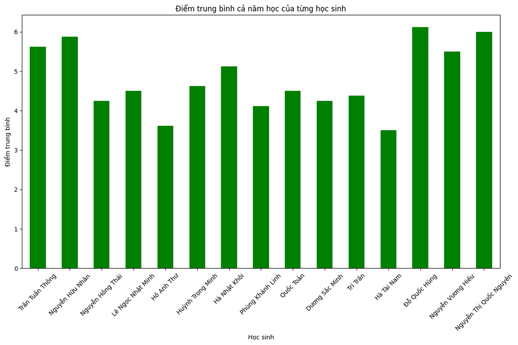

```python
# Tính tổng số điểm từng học sinh
tong_diem_moi_hs = df.sum(axis=1)

# Tính điểm trung bình cho cả năm học của từng học sinh
diem_trung_binh_hs = (tong_diem_moi_hs / df.shape[1]).round(2)

# Vẽ biểu đồ cột để trực quan hóa điểm trung bình
plt.figure(figsize=(12, 8))
diem_trung_binh_hs.plot(kind='bar', color='green')
plt.title('Điểm trung bình cả năm học của từng học sinh')
plt.xlabel('Học sinh')
plt.ylabel('Điểm trung bình')
plt.xticks(rotation=45)
plt.tight_layout()
plt.show()
```

```python
# - phân loại học sinh thành: "Ở lại lớp", "Trung bình", "Khá", "Giỏi", biết:
#     - học sinh "Giỏi"       : Nếu điểm trung bình >= 8.0, và không có môn nào dưới 6.5 điểm
#     - học sinh "Khá"        : Nếu điểm trung bình >= 6.5, và không có môn nào dưới 5 điểm
#     - học sinh "Trung bình" : Nếu điểm trung bình >= 5, và không có môn nào bị liệt
#     - "Ở lại lớp"           : Nếu học sinh đó dính bất kì một điểm liệt nào

# Tạo DataFrame chứa điểm liệt của từng học sinh
diem_liet_hs = df < 2.5

# Tính tổng số điểm từng học sinh
tong_diem_moi_hs = df.sum(axis=1)

# Tính điểm trung bình cho cả năm học của từng học sinh
diem_trung_binh_hs = (tong_diem_moi_hs / df.shape[1]).round(2)

# Khởi tạo danh sách để lưu phân loại của từng học sinh
phan_loai_hs = []

# Duyệt qua từng học sinh và xác định phân loại
for hs, diem_tb in diem_trung_binh_hs.items():
    if diem_tb >= 8.0 and not diem_liet_hs.loc[hs].any() and (diem_trung_binh_hs.loc[hs] >= 6.5).all():
        phan_loai_hs.append("Giỏi")
    elif diem_tb >= 6.5 and not diem_liet_hs.loc[hs].any() and (diem_trung_binh_hs.loc[hs] >= 5.0).all():
        phan_loai_hs.append("Khá")
    elif diem_tb >= 5.0 and not diem_liet_hs.loc[hs].any():
        phan_loai_hs.append("Trung bình")
    else:
        phan_loai_hs.append("Ở lại lớp")

# Thêm cột phân loại vào DataFrame
df['Phân loại'] = phan_loai_hs

# xoá cột này đi để còn chạy lại
# df = df.drop(columns=['Phân loại'])

# In ra kết quả phân loại của từng học sinh
print(df[['Phân loại']])
```

```
                         Phân loại
Trần Tuấn Thông          Ở lại lớp
Nguyễn Hữu Nhân         Trung bình
Nguyễn Hồng Thái         Ở lại lớp
Lê Ngọc Nhật Minh        Ở lại lớp
Hồ Anh Thư               Ở lại lớp
Huỳnh Trọng Minh         Ở lại lớp
Hà Nhật Khôi             Ở lại lớp
Phùng Khánh Linh         Ở lại lớp
Quốc Toản                Ở lại lớp
Dương Sắc Minh           Ở lại lớp
Trí Trần                 Ở lại lớp
Hà Tài Nam               Ở lại lớp
Đỗ Quốc Hùng             Ở lại lớp
Nguyễn Vương Hiếu       Trung bình
Nguyễn Thị Quốc Nguyên   Ở lại lớp
```

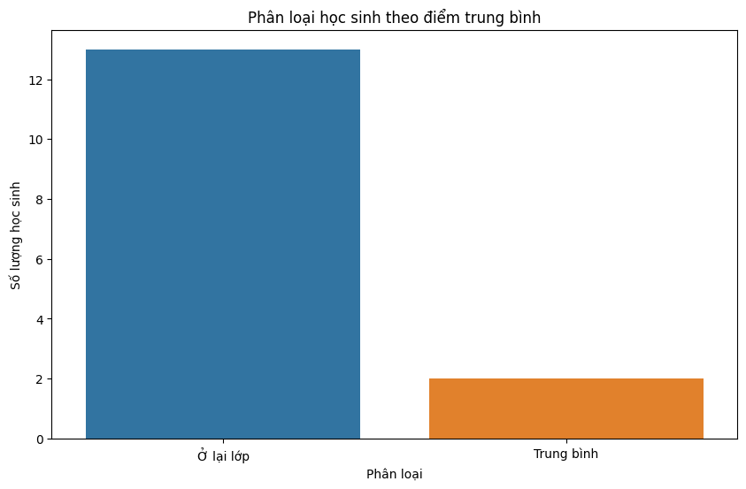

```python
# Tính số lượng học sinh trong mỗi nhóm phân loại
so_luong_phan_loai = df['Phân loại'].value_counts()

# Vẽ biểu đồ cột để trực quan hóa số lượng học sinh trong mỗi nhóm
plt.figure(figsize=(10, 6))
sns.barplot(x=so_luong_phan_loai.index, y=so_luong_phan_loai.values)
plt.title('Phân loại học sinh theo điểm trung bình')
plt.xlabel('Phân loại')
plt.ylabel('Số lượng học sinh')
plt.show()
```

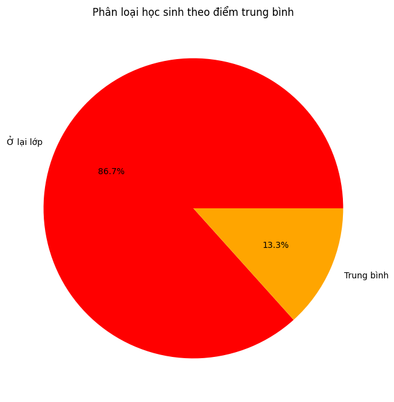

```python
# Tính số lượng học sinh trong mỗi nhóm phân loại
so_luong_phan_loai = df['Phân loại'].value_counts()

# Vẽ biểu đồ pie chart để trực quan hóa tỷ lệ phần trăm học sinh trong mỗi nhóm
plt.figure(figsize=(8, 8))
plt.pie(so_luong_phan_loai, labels=so_luong_phan_loai.index, autopct='%1.1f%%', colors=['red', 'orange', 'green', 'blue'])
plt.title('Phân loại học sinh theo điểm trung bình')
plt.show()
```

```python
# Tính điểm tốt nghiệp của từng học sinh, biết: điểm tốt nghiệp = điểm toán nhân đôi + điểm văn nhân đôi + điểm Anh + điểm sử

# Tính điểm tốt nghiệp cho từng học sinh
df['Điểm tốt nghiệp'] = (df['Toán'] * 2) + (df['Văn'] * 2) + df['Anh'] + df['Sử']

# In ra điểm tốt nghiệp của từng học sinh
print(df[['Điểm tốt nghiệp']])
```

```
                        Điểm tốt nghiệp
Trần Tuấn Thông                      36
Nguyễn Hữu Nhân                      30
Nguyễn Hồng Thái                     27
Lê Ngọc Nhật Minh                    35
Hồ Anh Thư                           20
Huỳnh Trọng Minh                     27
Hà Nhật Khôi                         27
Phùng Khánh Linh                     29
Quốc Toản                            34
Dương Sắc Minh                       24
Trí Trần                             27
Hà Tài Nam                           16
Đỗ Quốc Hùng                         35
Nguyễn Vương Hiếu                    25
Nguyễn Thị Quốc Nguyên               38
```

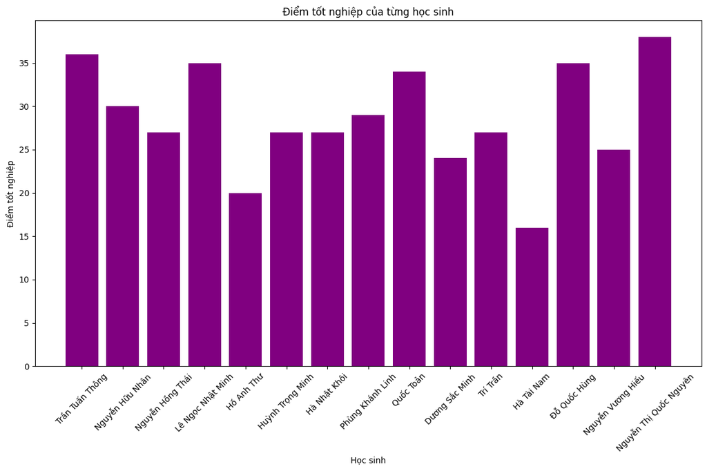

```python
# Tính điểm tốt nghiệp cho từng học sinh
df['Điểm tốt nghiệp'] = (df['Toán'] * 2) + (df['Văn'] * 2) + df['Anh'] + df['Sử']

# Vẽ biểu đồ cột để trực quan hóa điểm tốt nghiệp của từng học sinh
plt.figure(figsize=(12, 8))
plt.bar(df.index, df['Điểm tốt nghiệp'], color='purple')
plt.title('Điểm tốt nghiệp của từng học sinh')
plt.xlabel('Học sinh')
plt.ylabel('Điểm tốt nghiệp')
plt.xticks(rotation=45)
plt.tight_layout()
plt.show()
```

```python
# - Cho biết học sinh nào "Được tốt nghiệp" hoặc "Không đạt tốt nghiệp", biết để được công nhận xét tốt nghiệp, học sinh đó phải có điểm tốt nghiệp >= 30, và ko có môn nào bị điểm liệt
df['Tốt nghiệp'] = (df['Điểm tốt nghiệp'] >= 30) & (~df[diem_liet_hs].any(axis=1))
df['Kết quả'] = df['Tốt nghiệp'].apply(lambda x: 'Được tốt nghiệp' if x else 'Không đạt tốt nghiệp')
```

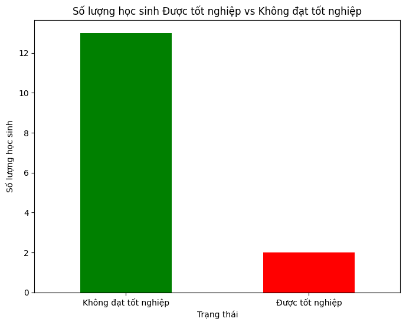

```python
plt.figure(figsize=(8, 6))
df['Kết quả'].value_counts().plot(kind='bar', color=['green', 'red'])
plt.title('Số lượng học sinh Được tốt nghiệp vs Không đạt tốt nghiệp')
plt.xlabel('Trạng thái')
plt.ylabel('Số lượng học sinh')
plt.xticks(rotation=0)
plt.show()
```

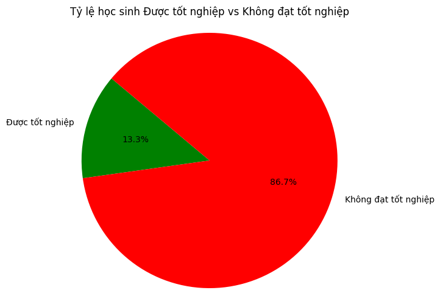

```python
# Tính số lượng học sinh trong mỗi trạng thái
total_count = len(df)
passed_count = df['Kết quả'].value_counts()['Được tốt nghiệp']
failed_count = df['Kết quả'].value_counts()['Không đạt tốt nghiệp']

# Tạo dữ liệu và nhãn cho biểu đồ pie chart
data = [passed_count, failed_count]
labels = ['Được tốt nghiệp', 'Không đạt tốt nghiệp']

# Vẽ biểu đồ pie chart
plt.figure(figsize=(8, 6))
plt.pie(data, labels=labels, autopct='%1.1f%%', startangle=140, colors=['green', 'red'])
plt.title('Tỷ lệ học sinh Được tốt nghiệp vs Không đạt tốt nghiệp')
plt.axis('equal')  # Đảm bảo biểu đồ hình tròn
plt.show()
```

```python
# - Nâng cao: Các thí sinh có quyền lựa chọn khối thi cho bản thân. cho biết các khối thi:
#     - Khối A    : Toán - Lý - Hoá
#     - Khối A1   : Toán - Lý - Anh
#     - Khối B    : Toán - Hoá - Sinh
#     - Khối C    : Văn - Sử - Địa
#     - Khối D    : Văn - Toán - Anh

#     ==> hãy cho biết: 2 nguyện vọng (2 khối thi) mà thí sinh đạt điểm cao nhất
#     (Trường hợp 2 khối thi có số điểm bằng nhau thì lấy cả 2)
#     Ví dụ: thi sinh Trần tuấn thông:
#             - Khối A    : Toán - Lý - Hoá    = (5 + 4 + 8) = 17
#             - Khối A1   : Toán - Lý - Anh    = (5 + 4 + 9) = 18
#             - Khối B    : Toán - Hoá - Sinh  = (5 + 8 + 2) = 15
#             - Khối C    : Văn - Sử - Địa     = (7 + 3 + 7) = 17
#             - Khối D    : Văn - Toán - Anh   = (7 + 5 + 9) = 21

#             ==> 2 nguyện vọng mà Trần Tuấn Thông đạt điểm cao nhất là khối D với 21 điểm và khối A1 với 18 điểm

# Tính điểm cho từng khối thi cho mỗi học sinh
df['Khối A'] = df['Toán'] + df['Lý'] + df['Hoá']
df['Khối A1'] = df['Toán'] + df['Lý'] + df['Anh']
df['Khối B'] = df['Toán'] + df['Hoá'] + df['Sinh']
df['Khối C'] = df['Văn'] + df['Sử'] + df['Địa']
df['Khối D'] = df['Văn'] + df['Toán'] + df['Anh']

# Lựa chọn 2 khối thi có điểm cao nhất cho từng học sinh
df['NV 1'] = df[['Khối A', 'Khối A1', 'Khối B', 'Khối C', 'Khối D']].idxmax(axis=1)
df['Điểm NV 1'] = df[['Khối A', 'Khối A1', 'Khối B', 'Khối C', 'Khối D']].max(axis=1)
df['NV 2'] = df[['Khối A', 'Khối A1', 'Khối B', 'Khối C', 'Khối D']].apply(lambda row: row.nlargest(2).index.tolist(), axis=1)
df['Điểm NV 2'] = df[['Khối A', 'Khối A1', 'Khối B', 'Khối C', 'Khối D']].apply(lambda row: row.nlargest(2).values.tolist(), axis=1)

# In ra kết quả cho từng học sinh
print(df[['NV 1', 'Điểm NV 1', 'NV 2', 'Điểm NV 2']])
```

```
                           NV 1  Điểm NV 1               NV 2 Điểm NV 2
Trần Tuấn Thông          Khối D         21  [Khối D, Khối A1]  [21, 18]
Nguyễn Hữu Nhân          Khối C         19   [Khối C, Khối A]  [19, 17]
Nguyễn Hồng Thái         Khối C         15   [Khối C, Khối D]  [15, 15]
Lê Ngọc Nhật Minh        Khối C         20   [Khối C, Khối D]  [20, 16]
Hồ Anh Thư               Khối B         15   [Khối B, Khối A]  [15, 14]
Huỳnh Trọng Minh         Khối C         16   [Khối C, Khối D]  [16, 16]
Hà Nhật Khôi             Khối B         18   [Khối B, Khối A]  [18, 16]
Phùng Khánh Linh        Khối A1         15  [Khối A1, Khối B]  [15, 15]
Quốc Toản                Khối A         19   [Khối A, Khối B]  [19, 19]
Dương Sắc Minh           Khối B         21   [Khối B, Khối A]  [21, 19]
Trí Trần                 Khối D         15   [Khối D, Khối C]  [15, 14]
Hà Tài Nam               Khối A         10  [Khối A, Khối A1]  [10, 10]
Đỗ Quốc Hùng             Khối C         21  [Khối C, Khối A1]  [21, 18]
Nguyễn Vương Hiếu        Khối A         18   [Khối A, Khối C]  [18, 18]
Nguyễn Thị Quốc Nguyên  Khối A1         20  [Khối A1, Khối A]  [20, 18]
```

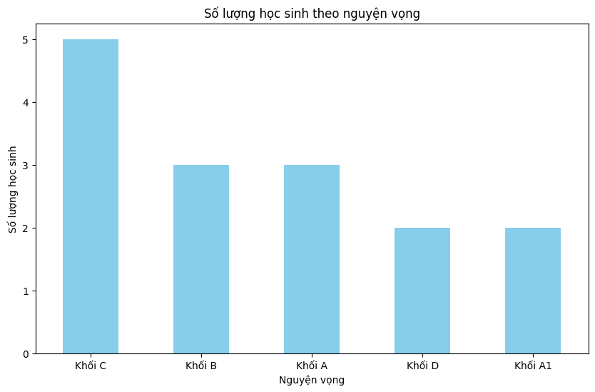

```python
# Tạo danh sách các cột nguyện vọng
nguyen_vong_cols = ['NV 1', 'NV 2']

# Lưu trữ dữ liệu nguyện vọng và điểm nguyện vọng cho từng học sinh
nguyen_vong_data = []
for index, row in df.iterrows():
    nguyen_vong_data.append(row[nguyen_vong_cols].values)

# Tạo DataFrame mới để lưu trữ dữ liệu nguyện vọng và điểm nguyện vọng
nguyen_vong_df = pd.DataFrame(nguyen_vong_data, columns=['Nguyện vọng', 'Điểm nguyện vọng'])

# Vẽ biểu đồ bar chart cho nguyện vọng 1 và nguyện vọng 2
plt.figure(figsize=(10, 6))
nguyen_vong_df['Nguyện vọng'].value_counts().plot(kind='bar', color='skyblue')
plt.title('Số lượng học sinh theo nguyện vọng')
plt.xlabel('Nguyện vọng')
plt.ylabel('Số lượng học sinh')
plt.xticks(rotation=0)
plt.show()
```

```python
df
```

|  | Toán | Văn | Anh | Sử | Địa | Lý | Hoá | Sinh | Phân loại | Điểm tốt nghiệp | ... | Kết quả | Khối A | Khối A1 | Khối B | Khối C | Khối D | NV 1 | Điểm NV 1 | NV 2 | Điểm NV 2 |
| --- | --- | --- | --- | --- | --- | --- | --- | --- | --- | --- | --- | --- | --- | --- | --- | --- | --- | --- | --- | --- | --- |
| Trần Tuấn Thông | 5 | 7 | 9 | 3 | 7 | 4 | 8 | 2 | Ở lại lớp | 36 | ... | Không đạt tốt nghiệp | 17 | 18 | 15 | 17 | 21 | Khối D | 21 | [Khối D, Khối A1] | [21, 18] |
| Nguyễn Hữu Nhân | 3 | 6 | 8 | 4 | 9 | 6 | 8 | 3 | Trung bình | 30 | ... | Được tốt nghiệp | 17 | 17 | 14 | 19 | 17 | Khối C | 19 | [Khối C, Khối A] | [19, 17] |
| Nguyễn Hồng Thái | 6 | 3 | 6 | 3 | 9 | 0 | 5 | 2 | Ở lại lớp | 27 | ... | Không đạt tốt nghiệp | 11 | 12 | 13 | 15 | 15 | Khối C | 15 | [Khối C, Khối D] | [15, 15] |
| Lê Ngọc Nhật Minh | 4 | 9 | 3 | 6 | 5 | 5 | 4 | 0 | Ở lại lớp | 35 | ... | Được tốt nghiệp | 13 | 12 | 8 | 20 | 16 | Khối C | 20 | [Khối C, Khối D] | [20, 16] |
| Hồ Anh Thư | 7 | 0 | 0 | 6 | 5 | 3 | 4 | 4 | Ở lại lớp | 20 | ... | Không đạt tốt nghiệp | 14 | 10 | 15 | 11 | 7 | Khối B | 15 | [Khối B, Khối A] | [15, 14] |
| Huỳnh Trọng Minh | 4 | 6 | 6 | 1 | 9 | 1 | 5 | 5 | Ở lại lớp | 27 | ... | Không đạt tốt nghiệp | 10 | 11 | 14 | 16 | 16 | Khối C | 16 | [Khối C, Khối D] | [16, 16] |
| Hà Nhật Khôi | 5 | 6 | 1 | 4 | 5 | 7 | 4 | 9 | Ở lại lớp | 27 | ... | Không đạt tốt nghiệp | 16 | 13 | 18 | 15 | 12 | Khối B | 18 | [Khối B, Khối A] | [18, 16] |
| Phùng Khánh Linh | 9 | 4 | 2 | 1 | 7 | 4 | 0 | 6 | Ở lại lớp | 29 | ... | Không đạt tốt nghiệp | 13 | 15 | 15 | 12 | 15 | Khối A1 | 15 | [Khối A1, Khối B] | [15, 15] |
| Quốc Toản | 8 | 6 | 1 | 5 | 3 | 2 | 9 | 2 | Ở lại lớp | 34 | ... | Không đạt tốt nghiệp | 19 | 11 | 19 | 14 | 15 | Khối A | 19 | [Khối A, Khối B] | [19, 19] |
| Dương Sắc Minh | 6 | 5 | 0 | 2 | 2 | 4 | 9 | 6 | Ở lại lớp | 24 | ... | Không đạt tốt nghiệp | 19 | 10 | 21 | 9 | 11 | Khối B | 21 | [Khối B, Khối A] | [21, 19] |
| Trí Trần | 1 | 9 | 5 | 2 | 3 | 4 | 7 | 4 | Ở lại lớp | 27 | ... | Không đạt tốt nghiệp | 12 | 10 | 12 | 14 | 15 | Khối D | 15 | [Khối D, Khối C] | [15, 14] |
| Hà Tài Nam | 1 | 6 | 1 | 1 | 3 | 8 | 1 | 7 | Ở lại lớp | 16 | ... | Không đạt tốt nghiệp | 10 | 10 | 9 | 10 | 8 | Khối A | 10 | [Khối A, Khối A1] | [10, 10] |
| Đỗ Quốc Hùng | 5 | 7 | 6 | 5 | 9 | 7 | 1 | 9 | Ở lại lớp | 35 | ... | Không đạt tốt nghiệp | 13 | 18 | 15 | 21 | 18 | Khối C | 21 | [Khối C, Khối A1] | [21, 18] |
| Nguyễn Vương Hiếu | 3 | 6 | 4 | 3 | 9 | 8 | 7 | 4 | Trung bình | 25 | ... | Không đạt tốt nghiệp | 18 | 15 | 14 | 18 | 13 | Khối A | 18 | [Khối A, Khối C] | [18, 18] |
| Nguyễn Thị Quốc Nguyên | 6 | 5 | 7 | 9 | 2 | 7 | 5 | 7 | Ở lại lớp | 38 | ... | Không đạt tốt nghiệp | 18 | 20 | 18 | 16 | 18 | Khối A1 | 20 | [Khối A1, Khối A] | [20, 18] |

15 rows × 21 columns